# Preprocesamiento de datos

Kevin Miguel Yax Puac

2026-07-16

## Carga de datos

¿Como visualizamos los primeros datos?

```
## , , Age = Child, Survived = No
##
##       Sex
## Class  Male Female
##   1st     0      0
##   2nd     0      0
##   3rd    35     17
##   Crew    0      0
##
## , , Age = Adult, Survived = No
##
##       Sex
## Class  Male Female
##   1st   118      4
##   2nd   154     13
##   3rd   387     89
##   Crew  670      3
##
## , , Age = Child, Survived = Yes
##
##       Sex
## Class  Male Female
##   1st     5      1
##   2nd    11     13
##   3rd    13     14
##   Crew    0      0
##
## , , Age = Adult, Survived = Yes
##
##       Sex
## Class  Male Female
##   1st    57    140
##   2nd    14     80
##   3rd    75     76
##   Crew  192     20
```

¿Como hacemos para saber de que tipo son los datos (texto/numero)?

```
##  'table' num [1:4, 1:2, 1:2, 1:2] 0 0 35 0 0 0 17 0 118 154 ...
##  - attr(*, "dimnames")=List of 4
##   ..$ Class   : chr [1:4] "1st" "2nd" "3rd" "Crew"
##   ..$ Sex     : chr [1:2] "Male" "Female"
##   ..$ Age     : chr [1:2] "Child" "Adult"
##   ..$ Survived: chr [1:2] "No" "Yes"
```

## Limpieza de datos

¿Cuantos datos faltantes hay para la variable edad (Age)?

```
## [1] 177
```

Si los eliminamos perdemos demasiada informacion ¿Que hacemos?

Solucion: **Imputarlos** (imputar a la Media o la Mediana) Recordatorio: La media se ve afectada por los *valores atipicos (outliers)*

## Analisis Exploratorio de datos (EDA) con graficos

Como determinamos si los ninios (Age < 12) sobrevivieron mas? generamos una columna llamada ‘Child’

## Nivel 1: R Base (Sin incluir ningun paquete)

Ideal para entender la logica sin dependencias

### Tabla de contigencia (Frecuencias)

Cuanto hombresy mujeres sobrevivieron?

```
##
##            0   1
##   female  81 233
##   male   468 109
```

```
##
##                 0        1
##   female 25.79618 74.20382
##   male   81.10919 18.89081
```

## Box Plot (Edad vs Supervivencia)

La edad de los que sobrevivieron es similar a la edad de las que no lo hicieron?

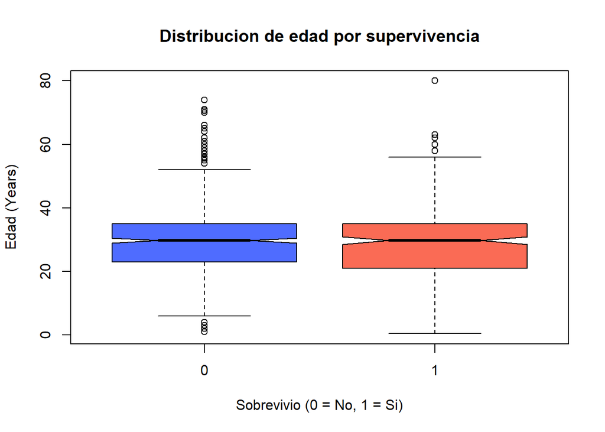

# Barplot de supervivencia por clase

La clase influyo en la supervivencia?

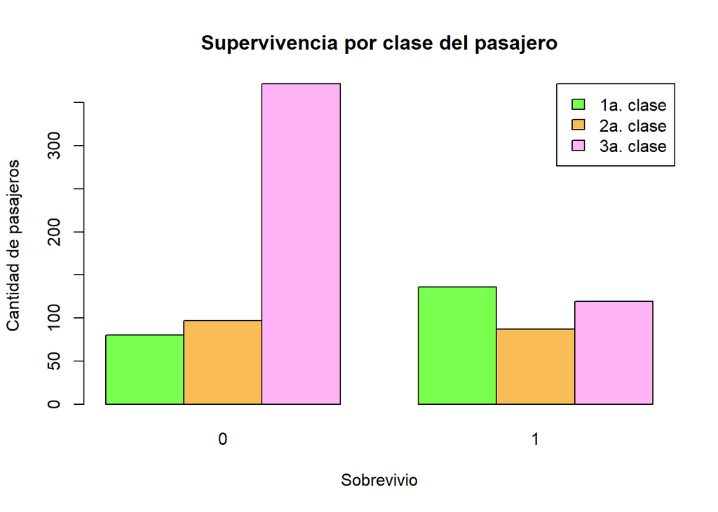

Que porcentaje de cada clase sobrevivio?

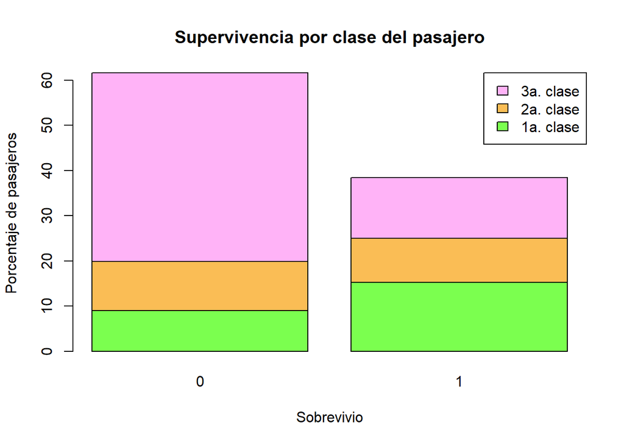

## Nivel 2: GGPLOT2 (Mas profesional y estetico)

### Boxplot con ggplot2 (el mas utilizado)

Que grupo tiene mayor edad? (observar las madianas)

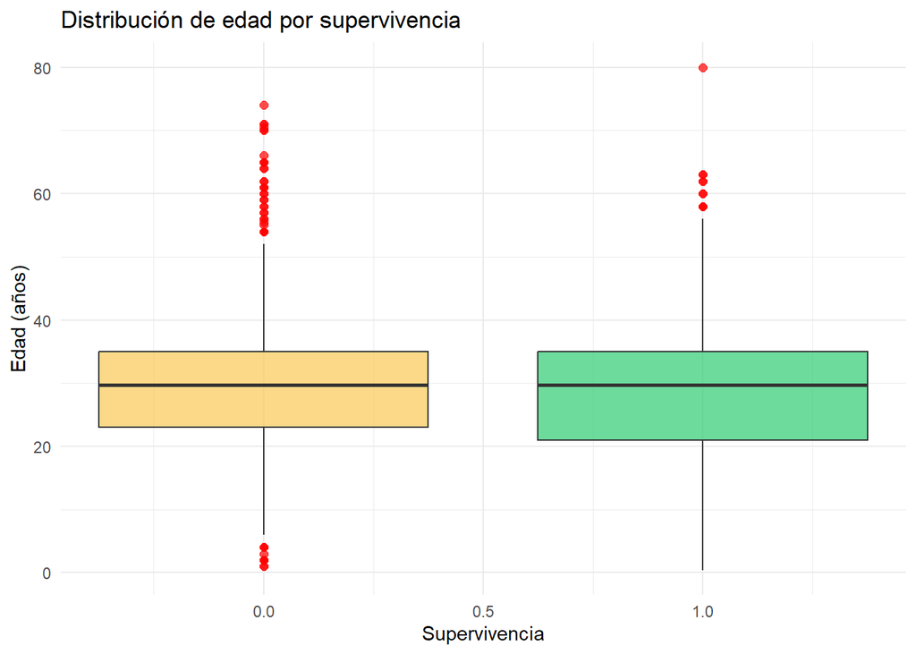

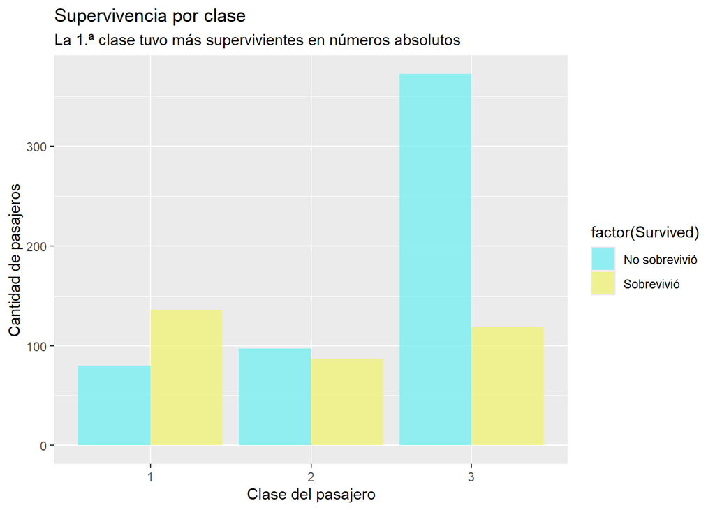

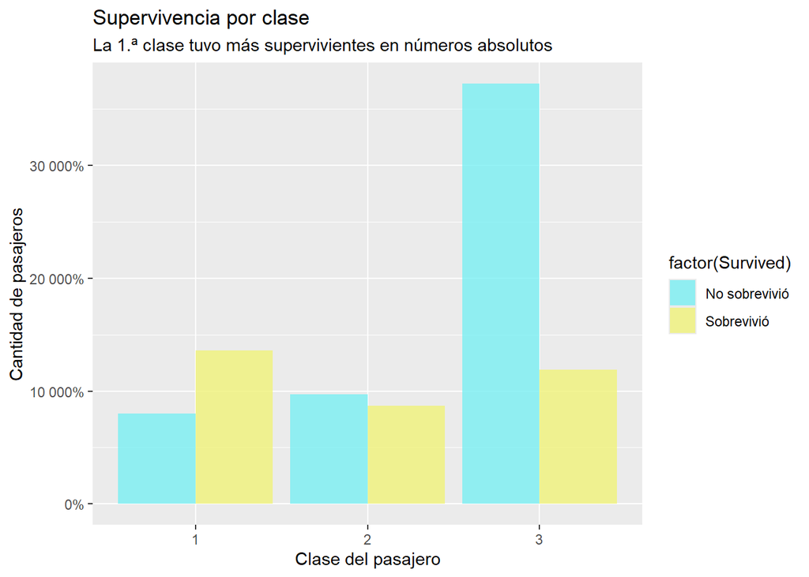

### Relacion entre Edad, Clase y Supervivencia (Mas avanzado)

Los ninios de la 3a. clase tuvieron la misma oportunidad de supervivencia que los ninios de la 1a. clase?

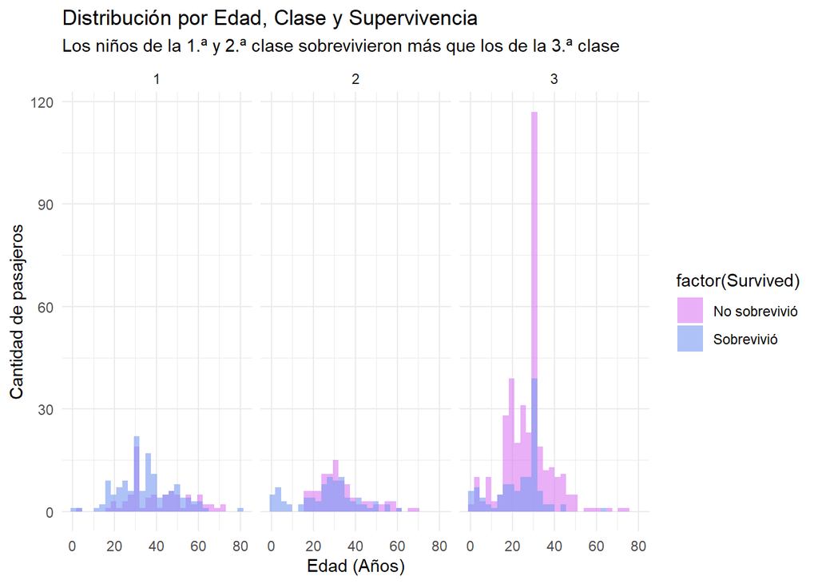

## Nivel 3: DPLYR + GGPLOT (Flujo de trabajo profesional) Encadenar procesos de trabajo (pipe)

1. Calcular la tasa de supervivencia por genero y clase.

```
## # A tibble: 6 × 6
##   Sex    Pclass Sobrevivieron Total Tasa_supervivencia Edad_media
##   <fct>  <fct>          <int> <int>              <dbl>      <dbl>
## 1 female 1                 91    94               96.8       34.1
## 2 female 2                 70    76               92.1       28.7
## 3 female 3                 72   144               50         24.1
## 4 male   1                 45   122               36.9       39.3
## 5 male   2                 17   108               15.7       30.7
## 6 male   3                 47   347               13.5       27.4
```

```
## Ignoring unknown labels:
## • tittle : "Tasa de Supervivencia por Genero y Clase"
```

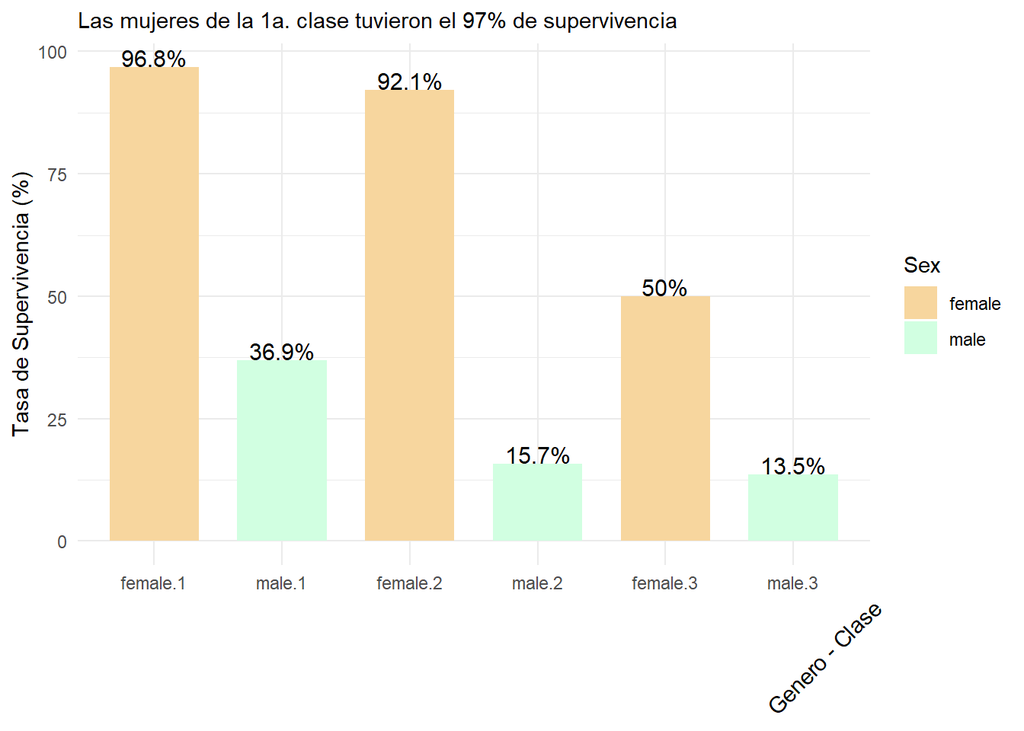

## Visualizaciones multiples

### Con GGPLOT y GridExtra

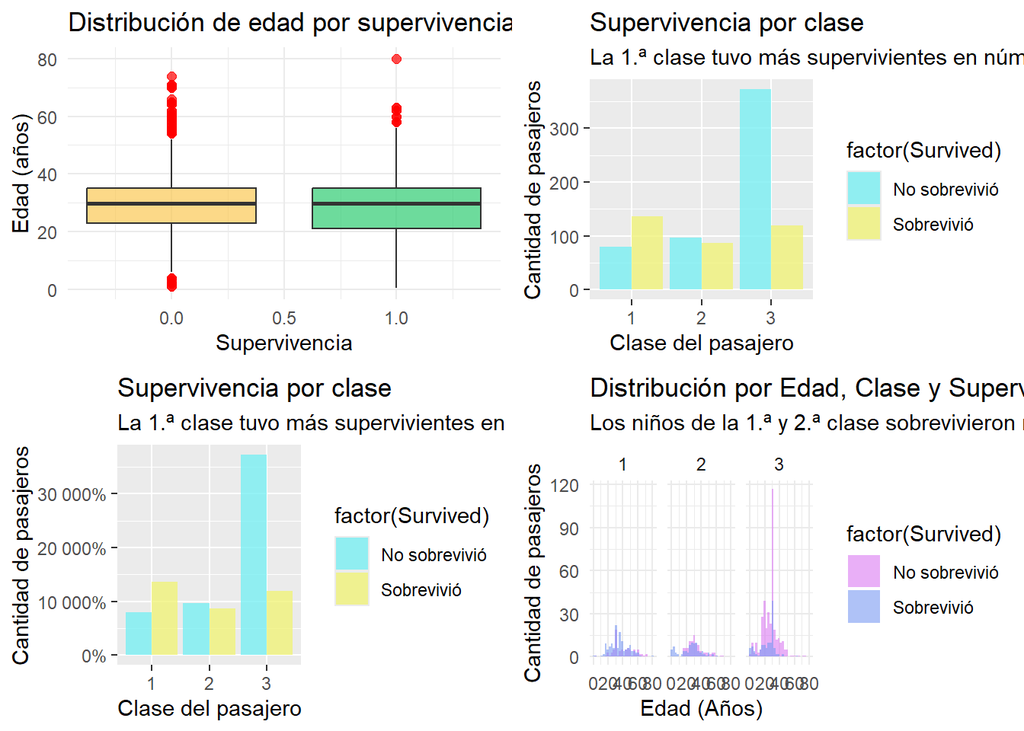

### Con R base

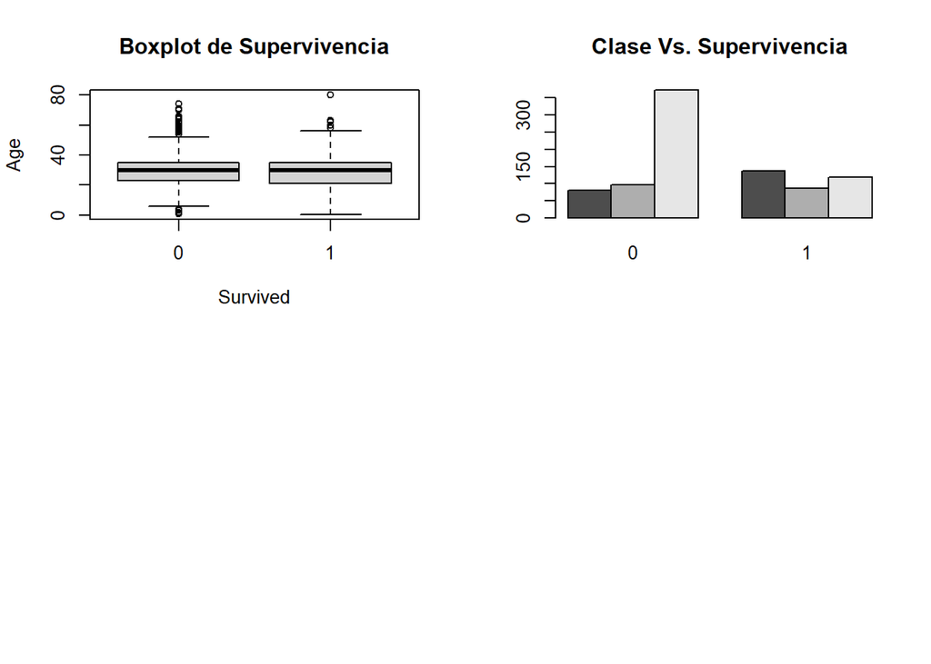